# Caret Functionality

## Level2; Tidy covariates (new covariates)

- More necessary for some methods (regression,svms) than for others (classification trees).
- Should be done only on the training set.
- The best approach is through exploratory analysis (plotting/tables).
- New covariates should be added to data frames.
- Building features/covariates can happen in the training set only and not in the test set.

```r
library(ISLR)
library(ggplot2)
library(lattice)
library(caret)
data(Wage)
inTrain <-createDataPartition(y=Wage$wage,p=0.7,list=FALSE)
training <-Wage[inTrain,]
testing <-Wage[-inTrain,]
#common covariates to add,dummy variables
#Basic idea; convert factor variables to indicator variables
table(training$jobclass)
```

```
##
##  1. Industrial 2. Information
##           1051           1051
```

```r
dummies <-dummyVars(wage~jobclass,data=training)
head(predict(dummies,newdata=training))
```

```
##        jobclass.1. Industrial jobclass.2. Information
## 86582                       0                       1
## 161300                      1                       0
## 155159                      0                       1
## 11443                       0                       1
## 376662                      0                       1
## 450601                      1                       0
```

```r
#Removing zero(0) covariates
nsv <-nearZeroVar(training,saveMetrics=TRUE)
nsv
```

```
##            freqRatio percentUnique zeroVar   nzv
## year        1.037356    0.33301618   FALSE FALSE
## age         1.027027    2.85442436   FALSE FALSE
## maritl      3.272931    0.23786870   FALSE FALSE
## race        8.938776    0.19029496   FALSE FALSE
## education   1.389002    0.23786870   FALSE FALSE
## region      0.000000    0.04757374    TRUE  TRUE
## jobclass    1.000000    0.09514748   FALSE FALSE
## health      2.468647    0.09514748   FALSE FALSE
## health_ins  2.352472    0.09514748   FALSE FALSE
## logwage     1.061728   19.17221694   FALSE FALSE
## wage        1.061728   19.17221694   FALSE FALSE
```

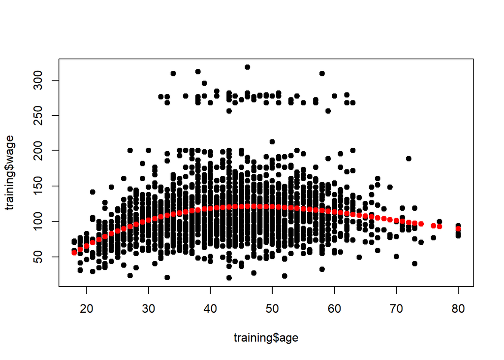

```r
library(splines)
bsBasis <-bs(training$age,df=3)

#Fitting curves with Splines
lm1 <-lm(wage~bsBasis,data=training)
plot(training$age,training$wage,pch=19,cex=1)
points(training$age,predict(lm1,newdata=training),col="red",pch=19,cex=1)
```

```r
#Splines on the test set
prediction <-predict(bsBasis,age=testing$age)
```

## Notes and further reading

- Level1 feature creation (raw data to covariates).
1. Science is key, Google “feature extraction for (data type)”.
2. Err on over creation of features.
3. In some applications(images,voices) automated feature creation is possible/necessary.
4. http://www.cs.nyu.edu/~yann/talks/lecun-ranzato-icml2013.pdf
- Level2 feature creation (covariates to new covariates).
1. The function preProcess in caret will handle some preprocessing.
2. Create new covariates if you think they will improve fit.
3. Use exploratory analysis on the training set for creating them.
4. Be careful about overfitting.
- preProcess with caret.
- If you want to fit spline models, use the gam method in the caret package which allows smoothing of multiple variables.
- More on feature creation/data tidying in the obtaining Data course from the Data Science.